# Snap2bmat - SnapATAC data processing

```r
  library(SingleCellExperiment)
```

This processing pipeline follows the [SnapATAC integration vignette](https://github.com/r3fang/SnapATAC/blob/master/examples/10X_PBMC_15K/README.md).

### Load Snap file

First I have made the snap file from the cellranger `fragments.tsv` file. Script is `multiOmic_benchmark/preprocess/fragments2snap.sh`.

```r
snap.files <- "~/my_data/cellranger-atac110_count_30439_WSSS8038360_GRCh38-1_1_0.snap"
sample.names <- "F74"
barcode.files <- '~/my_data/singlecell.csv'

x.sp.ls <- list(createSnap(snap.files, sample.names))
names(x.sp.ls) = sample.names
x.sp.ls
```

[output not shown]

### Barcode selection

Filtering based on number of reads per cell and ratio of fragments that are within promoters

```r
snap.files <- "~/my_data/cellranger-atac110_count_30439_WSSS8038360_GRCh38-1_1_0.snap"
sample.names <- "F74"
barcode.files <- '~/my_data/singlecell.csv'

x.sp.ls <- list(createSnap(snap.files, sample.names))
```

```
Epoch: reading the barcode session ...
```

```r
names(x.sp.ls) = sample.names
x.sp.ls
```

```
$F74
number of barcodes: 502490
number of bins: 0
number of genes: 0
number of peaks: 0
number of motifs: 0
```

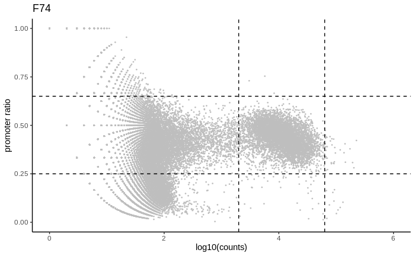

```r
barcode.ls = lapply(seq(snap.files), function(i){
    barcodes = read.csv(
        barcode.files[i],
        head=TRUE
    );
    # remove NO BAROCDE line
    barcodes = barcodes[2:nrow(barcodes),];
    barcodes$logUMI = log10(barcodes$passed_filters + 1);
    barcodes$promoter_ratio = (barcodes$promoter_region_fragments+1) / (barcodes$passed_filters + 1);
    barcodes
  })

plots = lapply(seq(snap.files), function(i){
    p1 = ggplot(
        barcode.ls[[i]],
        aes(x=logUMI, y=promoter_ratio)) +
        geom_point(size=0.3, col="grey") +
        theme_classic() +
        ggtitle(sample.names[[i]]) +
        ylim(0, 1) + xlim(0, 6) +
        labs(x = "log10(counts)", y="promoter ratio")
        p1
    })

## Select and viz cutoffs
cutoff.logUMI.low = 3.3
cutoff.logUMI.high = 4.8
cutoff.FRIP.low = 0.25
cutoff.FRIP.high = 0.65


plots[[1]] +
  geom_vline(xintercept = c(cutoff.logUMI.low[1],cutoff.logUMI.high[1]), linetype=2) +
  geom_hline(yintercept = c(cutoff.FRIP.low[1],cutoff.FRIP.high[1]), linetype=2)
```

```r
barcode.ls = lapply(seq(snap.files), function(i){
  barcodes = barcode.ls[[i]];
  idx = which(
      barcodes$logUMI >= cutoff.logUMI.low[i] &
      barcodes$logUMI <= cutoff.logUMI.high[i] &
      barcodes$promoter_ratio >= cutoff.FRIP.low[i] &
      barcodes$promoter_ratio <= cutoff.FRIP.high[i]
  );
  barcodes[idx,]
});
x.sp.ls = lapply(seq(snap.files), function(i){
  barcodes = barcode.ls[[i]];
  x.sp = x.sp.ls[[i]];
  barcode.shared = intersect(x.sp@barcode, barcodes$barcode);
  x.sp = x.sp[match(barcode.shared, x.sp@barcode),];
  barcodes = barcodes[match(barcode.shared, barcodes$barcode),];
  x.sp@metaData = barcodes;
  x.sp
})
names(x.sp.ls) = sample.names;
x.sp = Reduce(snapRbind, x.sp.ls);
x.sp@metaData["sample"] = x.sp@sample;
x.sp
```

```
number of barcodes: 6043
number of bins: 0
number of genes: 0
number of peaks: 0
number of motifs: 0
```

### Add cell-by-bin matrix

```r
x.sp = addBmatToSnap(x.sp, bin.size = 5000)
```

```
Epoch: reading cell-bin count matrix session ...
```

### Binarize matrix

Some items in the count matrix have abnormally high coverage perhaps due to the alignment errors. Therefore, we next remove top 0.1% items in the count matrix and then convert the remaining non-zero values to 1.

```r
x.sp = makeBinary(x.sp, mat="bmat")
x.sp
```

```
number of barcodes: 6043
number of bins: 651791
number of genes: 0
number of peaks: 0
number of motifs: 0
```

### Filter bins

Filter out bins overlapping with ENCODE blacklist

```r
black_list = read.table("~/annotations/hg38.blacklist.bed.gz")
black_list.gr = GRanges(
  black_list[,1],
  IRanges(black_list[,2], black_list[,3])
);
idy = queryHits(
  findOverlaps(x.sp@feature, black_list.gr)
);
if(length(idy) > 0){
  x.sp = x.sp[,-idy, mat="bmat"];
};
x.sp
```

```
number of barcodes: 6043
number of bins: 651765
number of genes: 0
number of peaks: 0
number of motifs: 0
```

Exclude bad chromosomes

```r
chr.exclude = seqlevels(x.sp@feature)[grep("random|chrM", seqlevels(x.sp@feature))]
idy = grep(paste(chr.exclude, collapse="|"), x.sp@feature)
if(length(idy) > 0){
  x.sp = x.sp[,-idy, mat="bmat"]
}
x.sp
```

```
number of barcodes: 6043
number of bins: 650342
number of genes: 0
number of peaks: 0
number of motifs: 0
```

remove the top 5% bins that overlap with invariant features such as the house keeping gene promoters

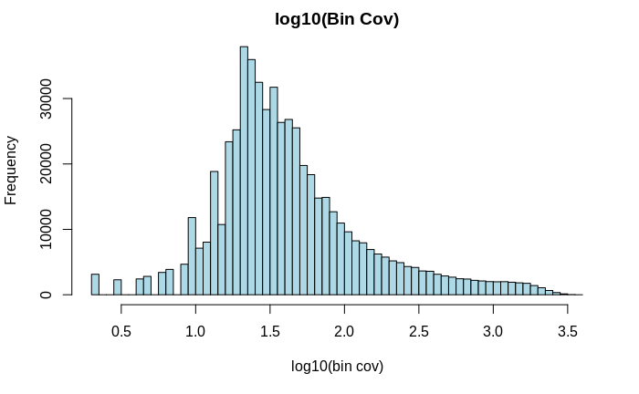

```r
bin.cov = log10(Matrix::colSums(x.sp@bmat)+1)
# bin.cov = Matrix::colSums(x.sp@bmat)
hist(
  bin.cov[bin.cov > 0],
  xlab="log10(bin cov)",
  main="log10(Bin Cov)",
  col="lightblue",
  # xlim=c(0, 5),
  breaks=100
);
```

```r
bin.cutoff = quantile(bin.cov[bin.cov > 0], 0.95)
idy = which(bin.cov <= bin.cutoff & bin.cov > 0)
x.sp = x.sp[, idy, mat="bmat"];
x.sp
```

```
number of barcodes: 6043
number of bins: 539584
number of genes: 0
number of peaks: 0
number of motifs: 0
```

Remove any cells of bin coverage less than 1,000. The rational behind this is that some cells may have high number of unique fragments but end up with low bin coverage after filtering. This step is optional but highly recommanded.

```r
idx = which(Matrix::rowSums(x.sp@bmat) > 1000);
x.sp = x.sp[idx,];
x.sp
```

```
number of barcodes: 5793
number of bins: 539584
number of genes: 0
number of peaks: 0
number of motifs: 0
```

## Dimensionality reduction with LSI

```r
bmat <- x.sp@bmat
bmat <- t(bmat)
rownames(bmat) <- x.sp@feature$name
meta <- x.sp@metaData %>% rownames_to_column() %>% select(- c(cell_id,rowname) ) %>% column_to_rownames("barcode")

bmat.seu <- CreateSeuratObject(counts = bmat, assay = "ATAC", min.cells = 100, meta.data = meta)
bmat.seu <- RunLSI(bmat.seu, n = 30)
```

[output not shown]

```r
bmat.seu <- FindNeighbors(bmat.seu, reduction = "lsi", dims = 1:30)
bmat.seu <- FindClusters(bmat.seu, algorithm = 4)
bmat.seu <- RunUMAP(bmat.seu, reduction = "lsi", dims = 1:30)
```

```
The default method for RunUMAP has changed from calling Python UMAP via reticulate to the R-native UWOT using the cosine metric
To use Python UMAP via reticulate, set umap.method to 'umap-learn' and metric to 'correlation'
This message will be shown once per session16:31:06 UMAP embedding parameters a = 0.9922 b = 1.112
```

```
Using `as.character()` on a quosure is deprecated as of rlang 0.3.0.
Please use `as_label()` or `as_name()` instead.
```

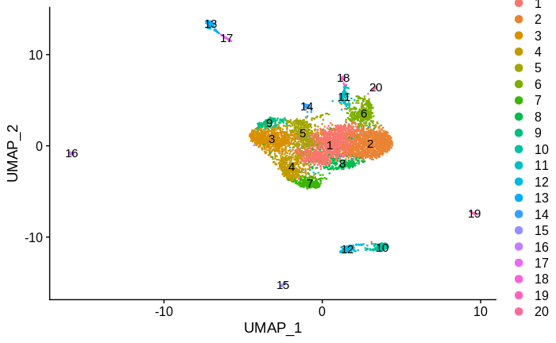

```r
DimPlot(bmat.seu, reduction = "umap", label = T)
```

## Make gene activity matrix (gmat)

Summing counts over gene body + 2kb upstream (promoter)

```r
transcripts.gr = rtracklayer::import("~/annotations/Homo_sapiens.GRCh38.93.filtered.gtf")
colnames(transcripts.gr@elementMetadata) <- str_replace(colnames(transcripts.gr@elementMetadata), "gene_name", "name")

genes.gr <- unlist(range(split(transcripts.gr, ~ name)))  ## From transcripts to genes
genes.gr$name <- names(genes.gr)

if (GenomeInfoDb::seqlevelsStyle(genes.gr) != GenomeInfoDb::seqlevelsStyle(x.sp@feature) ) {
  GenomeInfoDb::seqlevelsStyle(genes.gr) <- GenomeInfoDb::seqlevelsStyle(x.sp@feature)
}
```

```
the condition has length > 1 and only the first element will be used
```

```r
## Expand ranges to include promoter
expandRange = function(x, upstream=2000, downstream=1000) {
  strand_is_minus = strand(x) == "-"
  on_plus = which(!strand_is_minus)
  on_minus = which(strand_is_minus)
  start(x)[on_plus] = start(x)[on_plus] - upstream
  start(x)[on_minus] = start(x)[on_minus] - downstream
  end(x)[on_plus] = end(x)[on_plus] + downstream
  end(x)[on_minus] = end(x)[on_minus] + upstream
  x
}
genes.gr <- expandRange(genes.gr, downstream = 0)

## Make gmat
x.sp = createGmatFromMat(
    obj=x.sp,
    input.mat="bmat",
    genes=genes.gr,
    do.par=TRUE,
    num.cores=10
  )
```

[output not shown]

```r
gmat <- t(x.sp@gmat)
bmat.seu[["ACTIVITY"]] <- CreateAssayObject(counts=gmat)
```

```
Non-unique features (rownames) present in the input matrix, making unique
```

```r
cpm(thymus.atac.sce) <- as(object = cpm, Class = "dgCMatrix")
```

[output not shown]

## Make binary gmat and save

```r
makeBinGmat <- function(atac.sce){
  logcounts(atac.sce) <-
    logcounts(atac.sce) %>%
    as.matrix() %>%
    {ifelse(.==0, 0,1)}
  return(atac.sce)
}

bim.atac.sce <- makeBinGmat(thymus.atac.sce)

saveRDS(bim.atac.sce, "~/my_data/F74_ATAC_snapAtac_processed_bgmat.RDS")
```

```r
x.sp@gmat
```

```
5793 x 33517 sparse Matrix of class "dgCMatrix"
```

```
   [[ suppressing 55 column names ‘A1BG’, ‘A1BG-AS1’, ‘A1CF’ ... ]]
   [[ suppressing 55 column names ‘A1BG’, ‘A1BG-AS1’, ‘A1CF’ ... ]]
```

[output not shown]

```
   [[ suppressing 55 column names ‘A1BG’, ‘A1BG-AS1’, ‘A1CF’ ... ]]
```

[output not shown]